# Nilu Isakova

## Cardio Good Fitness Data Analysis

Description Objective

Explore the dataset to identify differences between the customers of each product. You can also explore relationships between the different attributes of the customers. You can approach it from any other line of questioning that you feel could be relevant for the business. The idea is to get you comfortable working in Python.

You are expected to do the following :

##### 1) Come up with a customer profile (characteristics of a customer) of the different products

##### 2) Perform univariate and multivariate analyses

##### 3) Generate a set of insights and recommendations that will help the company in targeting new customers.

Data Dictionary The data is about customers of the treadmill product(s) of a retail store called Cardio Good Fitness. It contains the following variables-

Product - The model no. of the treadmill Age - Age of the customer in no of years Gender - Gender of the customer Education - Education of the customer in no. of years Marital Status - Marital status of the customer Usage - Avg. # times the customer wants to use the treadmill every week Fitness - Self rated fitness score of the customer (5 - very fit, 1 - very unfit) Income - Income of the customer Miles- Miles that a customer expects to run

Best Practices for Notebook The notebook should be well-documented, with inline comments explaining the functionality of code and markdown cells containing comments on the observations and insights. The notebook should be run from start to finish in a sequential manner before submission. It is preferable to remove all warnings and errors before submission. The notebook should be submitted as an HTML file (.html) and NOT as a notebook file (.ipynb).

Submission Guidelines The submission should be a well-commented Jupyter notebook [format - .html] Any assignment found copied/ plagiarized with other groups will not be graded and awarded zero marks. Please ensure timely submission as any submission post-deadline will not be accepted for evaluation. Submission will not be evaluated if it is submitted post-deadline, or, more than 1 file is submitted.

# 1. How should one approach the Cardio Good Fitness project?

Before starting the project, please read the problem statement carefully and go through the criteria and descriptions mentioned in the rubric. Once you understand the task, download and import the dataset into a Jupyter notebook to get started with the project. To work on the project, you should start with exploratory data analysis. Try to use descriptive statistics and visualization to understand the data. Once the EDA is completed, you can use the data to start answering the business problem that we are trying to address. It is important to close the analysis with key findings and recommendations to the business.

# Import the necessary packages - pandas, numpy, seaborn, matplotlib.pyplot

```python
# importing all nessesary packages for the data analysis

import warnings
warnings.filterwarnings('ignore')   # to avoid warnings

import numpy as np
import pandas as pd
import seaborn as sns
import matplotlib.pyplot as plt
sns.set(style="darkgrid")

# This magic just sets up matplotlib's interactive mode
%matplotlib inline
```

[output not shown]

# Read the Dataset. Check info and shape. Display first 5 rows.

```python
cardio_gf_data = pd.read_csv('CardioGoodFitness.csv')
cardio_gf_data.head()
```

|  | Product | Age | Gender | Education | MaritalStatus | Usage | Fitness | Income | Miles |
| --- | --- | --- | --- | --- | --- | --- | --- | --- | --- |
| 0 | TM195 | 18 | Male | 14 | Single | 3 | 4 | 29562 | 112 |
| 1 | TM195 | 19 | Male | 15 | Single | 2 | 3 | 31836 | 75 |
| 2 | TM195 | 19 | Female | 14 | Partnered | 4 | 3 | 30699 | 66 |
| 3 | TM195 | 19 | Male | 12 | Single | 3 | 3 | 32973 | 85 |
| 4 | TM195 | 20 | Male | 13 | Partnered | 4 | 2 | 35247 | 47 |

Observations:

The dataset looks clean and consistent with the description provided in the data discription.

# Data information

```python
cardio_gf_data.info()
```

```
<class 'pandas.core.frame.DataFrame'>
RangeIndex: 180 entries, 0 to 179
Data columns (total 9 columns):
 #   Column         Non-Null Count  Dtype
---  ------         --------------  -----
 0   Product        180 non-null    object
 1   Age            180 non-null    int64
 2   Gender         180 non-null    object
 3   Education      180 non-null    int64
 4   MaritalStatus  180 non-null    object
 5   Usage          180 non-null    int64
 6   Fitness        180 non-null    int64
 7   Income         180 non-null    int64
 8   Miles          180 non-null    int64
dtypes: int64(6), object(3)
memory usage: 12.8+ KB
```

Observations:

no missing values in the dataset

# Check for any NA values in the cardio cardio_gf_data

```python
cardio_gf_data.isnull().sum()
```

```
Product          0
Age              0
Gender           0
Education        0
MaritalStatus    0
Usage            0
Fitness          0
Income           0
Miles            0
dtype: int64
```

Observations:

we can see that there is no na values in the dataset

# Checking the shape of the data

```python
cardio_gf_data.shape
```

```
(180, 9)
```

Observations: the dataset has 180 rows, 9 columns

# Check the datatype of the variables to make sure that the data is read in properly¶

```python
cardio_gf_data.dtypes
```

```
Product          object
Age               int64
Gender           object
Education         int64
MaritalStatus    object
Usage             int64
Fitness           int64
Income            int64
Miles             int64
dtype: object
```

Observations:

1) Product, Gender, MaritalStatus are object data type

2) All the other variables are numerical and there for their python data type int64 is ok.

# Let us analyse the quantitative variables in the dataset, check the summary statistics

```python
cardio_gf_data.describe()
```

|  | Age | Education | Usage | Fitness | Income | Miles |
| --- | --- | --- | --- | --- | --- | --- |
| count | 180.000000 | 180.000000 | 180.000000 | 180.000000 | 180.000000 | 180.000000 |
| mean | 28.788889 | 15.572222 | 3.455556 | 3.311111 | 53719.577778 | 103.194444 |
| std | 6.943498 | 1.617055 | 1.084797 | 0.958869 | 16506.684226 | 51.863605 |
| min | 18.000000 | 12.000000 | 2.000000 | 1.000000 | 29562.000000 | 21.000000 |
| 25% | 24.000000 | 14.000000 | 3.000000 | 3.000000 | 44058.750000 | 66.000000 |
| 50% | 26.000000 | 16.000000 | 3.000000 | 3.000000 | 50596.500000 | 94.000000 |
| 75% | 33.000000 | 16.000000 | 4.000000 | 4.000000 | 58668.000000 | 114.750000 |
| max | 50.000000 | 21.000000 | 7.000000 | 5.000000 | 104581.000000 | 360.000000 |

Observations:

```python
list_column = ["Product", "Age", "Gender", "Education", "MaritalStatus", "Usage", "Fitness","Income","Miles"]
for col in list_column:
    print("{}:{}".format(col,cardio_gf_data[col].unique()))
```

```
Product:['TM195' 'TM498' 'TM798']
Age:[18 19 20 21 22 23 24 25 26 27 28 29 30 31 32 33 34 35 36 37 38 39 40 41
 43 44 46 47 50 45 48 42]
Gender:['Male' 'Female']
Education:[14 15 12 13 16 18 20 21]
MaritalStatus:['Single' 'Partnered']
Usage:[3 2 4 5 6 7]
Fitness:[4 3 2 1 5]
Income:[ 29562  31836  30699  32973  35247  37521  36384  38658  40932  34110
  39795  42069  44343  45480  46617  48891  53439  43206  52302  51165
  50028  54576  68220  55713  60261  67083  56850  59124  61398  57987
  64809  47754  65220  62535  48658  54781  48556  58516  53536  61006
  57271  52291  49801  62251  64741  70966  75946  74701  69721  83416
  88396  90886  92131  77191  52290  85906 103336  99601  89641  95866
 104581  95508]
Miles:[112  75  66  85  47 141 103  94 113  38 188  56 132 169  64  53 106  95
 212  42 127  74 170  21 120 200 140 100  80 160 180 240 150 300 280 260
 360]
```

Observations:

Product: 3 product types (TM195, TM498, TM798) Age range: 18-50 Avg Income: $53719 Medium Treadmill usage: 3 times per week Years of education range: 12-21. Years of education average: 15

# Looking at the relationship between numerical variables using pair plots and correlation plots

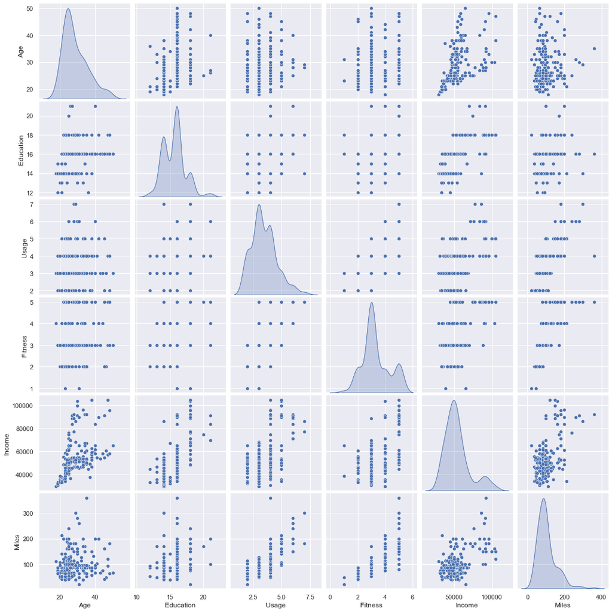

```python
# pairplot of cardio data
sns.pairplot(cardio_gf_data, diag_kind="kde")
```

Observations:

# Looking the Product types, relationship between Product Types, Gender and Age

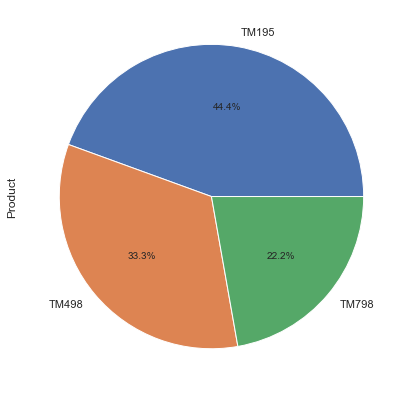

```python
plt.figure(figsize = (7,7))
cardio_gf_data["Product"].value_counts().plot.pie(autopct='%1.1f%%')
```

Observations:

Most used product: TM195

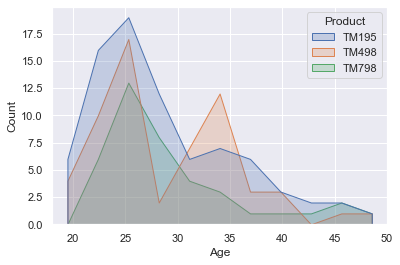

```python
sns.histplot(data = cardio_gf_data, x = "Age", hue = "Product", element = "poly")
```

Observations:

1) TM195: Majority of users' age is from 20-30

2) TM798: Majority of users' age is from 20-30

3) TM498: Users' ages are spread out for this product.

```python
# creating a 2-D Matrix with correlation plots
correlation = cardio_gf_data.corr()
correlation
```

|  | Age | Education | Usage | Fitness | Income | Miles |
| --- | --- | --- | --- | --- | --- | --- |
| Age | 1.000000 | 0.280496 | 0.015064 | 0.061105 | 0.513414 | 0.036618 |
| Education | 0.280496 | 1.000000 | 0.395155 | 0.410581 | 0.625827 | 0.307284 |
| Usage | 0.015064 | 0.395155 | 1.000000 | 0.668606 | 0.519537 | 0.759130 |
| Fitness | 0.061105 | 0.410581 | 0.668606 | 1.000000 | 0.535005 | 0.785702 |
| Income | 0.513414 | 0.625827 | 0.519537 | 0.535005 | 1.000000 | 0.543473 |
| Miles | 0.036618 | 0.307284 | 0.759130 | 0.785702 | 0.543473 | 1.000000 |

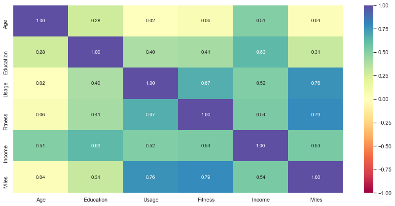

```python
# Uncomment the following code for information of the arguments
# help(sns.heatmap)
plt.figure(figsize=(15, 7))
sns.heatmap(correlation, annot=True, vmin=-1, vmax=1, fmt=".2f", cmap="Spectral")
plt.show()
```

Observations:

```python
cardio_gf_data.head()
```

|  | Product | Age | Gender | Education | MaritalStatus | Usage | Fitness | Income | Miles |
| --- | --- | --- | --- | --- | --- | --- | --- | --- | --- |
| 0 | TM195 | 18 | Male | 14 | Single | 3 | 4 | 29562 | 112 |
| 1 | TM195 | 19 | Male | 15 | Single | 2 | 3 | 31836 | 75 |
| 2 | TM195 | 19 | Female | 14 | Partnered | 4 | 3 | 30699 | 66 |
| 3 | TM195 | 19 | Male | 12 | Single | 3 | 3 | 32973 | 85 |
| 4 | TM195 | 20 | Male | 13 | Partnered | 4 | 2 | 35247 | 47 |

# Let us now explore the categorical features - Product

```python
print(cardio_gf_data.Product.nunique())
```

```
3
```

Observations: we have only three products that used by cunstomers

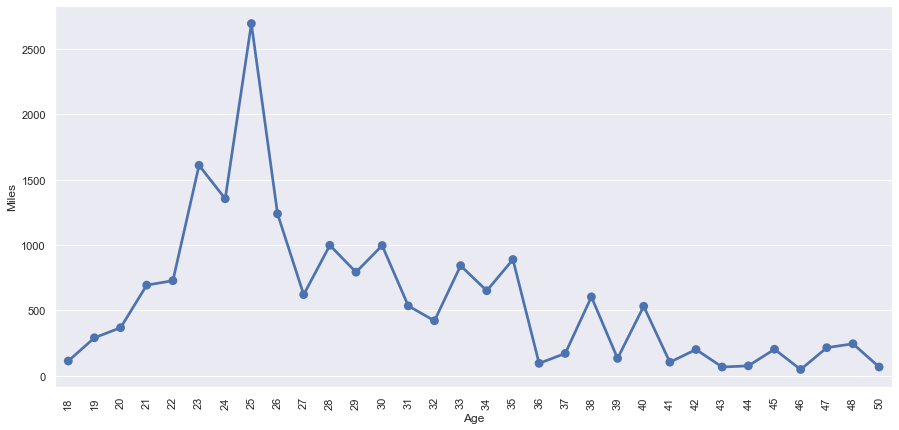

```python
plt.figure(figsize=(15, 7))
sns.pointplot(x='Age', y='Miles', data=cardio_gf_data, estimator=sum, ci=None)
plt.xticks(rotation=90) # To rotate the x axis labls
plt.show()
```

Observations:

The overall Miles were increased between the age of 18 and 26, and after 27 age we can see that the miles were dicreased slowly.

# Distribution plot of Age, Education and boxplot plot of Income

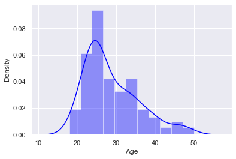

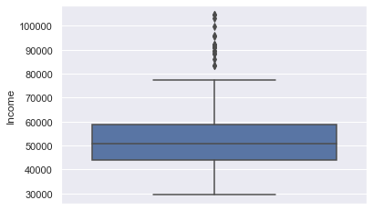

```python
sns.distplot(cardio_gf_data['Age'],color='blue')
plt.show()

sns.boxplot(y='Income',data=cardio_gf_data)
plt.show()
```

Observations:

from the distribution plot we can see that the majority of the people are in between 20-40 years of age

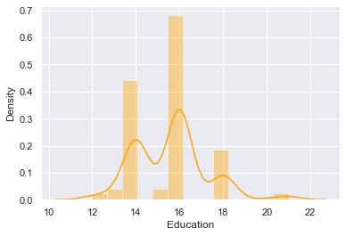

```python
# distribution plot of Education
sns.distplot(cardio_gf_data['Education'],color='orange')
plt.show()
```

Observations:

# Distribution plot of Usage, Fitness, Income, Miles

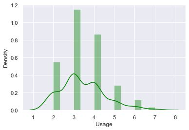

```python
# distribution plot of Usage
sns.distplot(cardio_gf_data['Usage'],color='green')
plt.show()
```

Observations:

From the plot we can se that most of the people want to use the treadmill in 2-5 times in a week

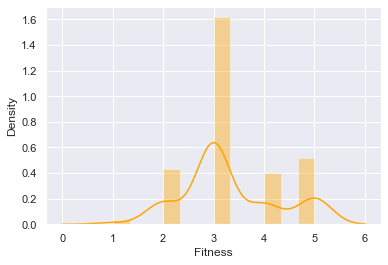

```python
# distribution plot of Fitness
sns.distplot(cardio_gf_data['Fitness'],color='orange')
plt.show()
```

Observations:

From the plot we can say that majority of the people reated them selves as # 3 fitness

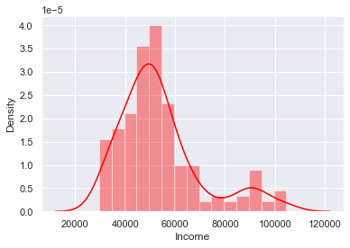

```python
# distribution plot of Income
sns.distplot(cardio_gf_data['Income'],color='red')
plt.show()
```

Observations:

The distribution plot shows us the income of the customer is between 40k and 60k

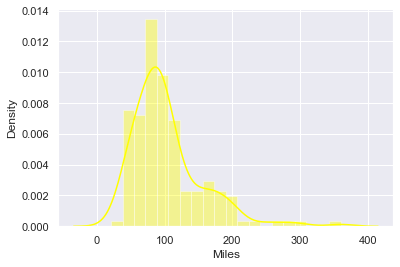

```python
# distribution plot of Miles
sns.distplot(cardio_gf_data['Miles'],color='yellow')
plt.show()
```

Observations:

From the plot we can see that the customers expect to run mostly 100 miles

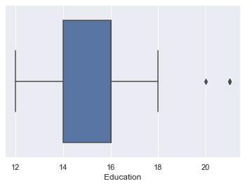

```python
# box plot of education
sns.boxplot(cardio_gf_data['Education'],orient='v')
plt.show()
```

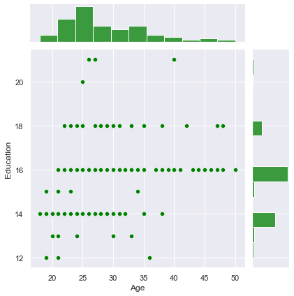

```python
# jointplot of Age and Education
sns.jointplot(cardio_gf_data['Age'], cardio_gf_data['Education'],color='green')
plt.show()
```

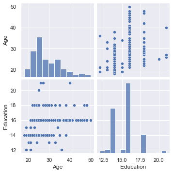

```python
# pair plot of Age and Education
sns.pairplot(cardio_gf_data[['Age','Education']])
plt.show()
```

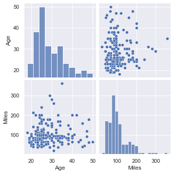

```python
# pair plot of Age and Miles
sns.pairplot(cardio_gf_data[['Age','Miles']])
plt.show()
```

from the plot we can see that customers between the age of 20-30 expect to run 100 miles

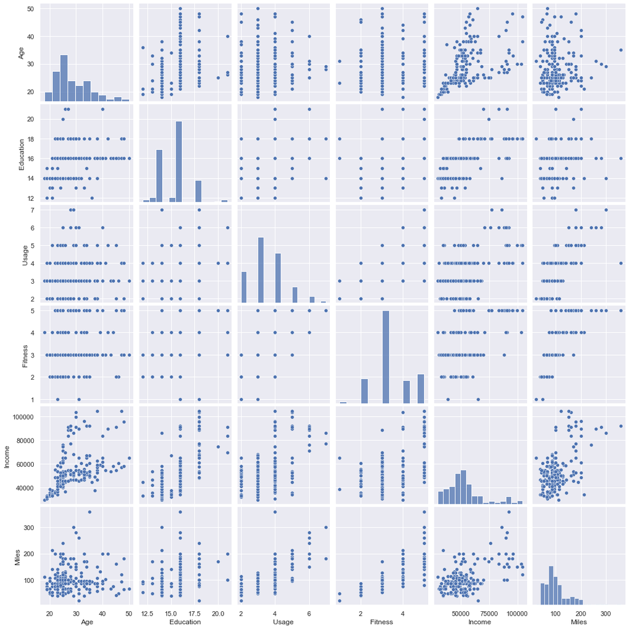

```python
# pair plot of the cardio_gf_data
sns.pairplot(cardio_gf_data[['Product','Age','Gender','Education','MaritalStatus','Usage','Fitness','Income','Miles']])
plt.show()
```

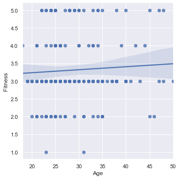

```python
# linear plot of Age and Fitness relationship
sns.lmplot(x = "Age",y = "Fitness", data = cardio_gf_data)
plt.show()
```

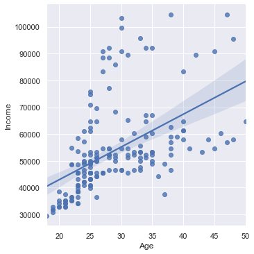

```python
# linear plot of Age and Income relationship
sns.lmplot(x = "Age",y = "Income", data = cardio_gf_data)
plt.show()
```

A linear realtionship can be observed as the Age amount increases so does the Income

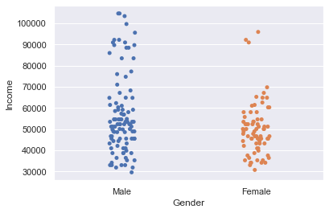

```python
# stripplot of Gender and Income
sns.stripplot(cardio_gf_data['Gender'], cardio_gf_data['Income'])
plt.show()
```

the plot shows us male income is higher than female income

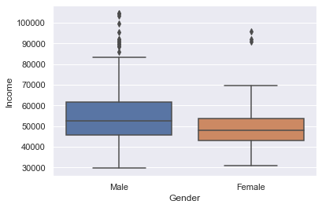

```python
# boxplot of Gender and Income
sns.boxplot(cardio_gf_data['Gender'], cardio_gf_data['Income'])
plt.show()
```

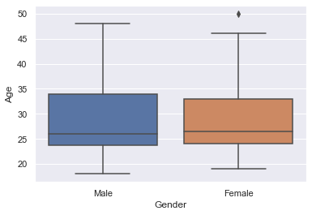

```python
# boxplot of Gender and Age
sns.boxplot(cardio_gf_data['Gender'], cardio_gf_data['Age'])
plt.show()
```

```python
pd.crosstab(cardio_gf_data["Product"],cardio_gf_data["Gender"])
```

| Gender Product | Female | Male |
| --- | --- | --- |
| TM195 | 40 | 40 |
| TM498 | 29 | 31 |
| TM798 | 7 | 33 |

Median value for Income is almost same for both, but male have a lot of outliers giving higher income

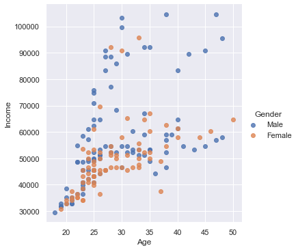

```python
# linear plot of Age, Income realtionship with gender hue
sns.lmplot(x='Age',y='Income',data=cardio_gf_data,fit_reg=False,hue='Gender')
plt.show()
```

Outliers with higher income amount and Age are males

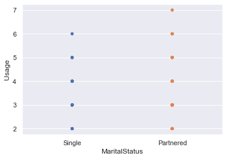

```python
# stripplot of MaritalStatus fitness Usage relationship
sns.stripplot(x='MaritalStatus',y='Usage',data=cardio_gf_data,jitter=False)
plt.show()
```

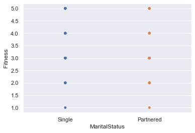

```python
# stripplot of MaritalStatus fitness Fitness relationship
sns.stripplot(x='MaritalStatus',y='Fitness',data=cardio_gf_data,jitter=False)
plt.show()
```

from the plot we do not see any difference between marital status and fitness

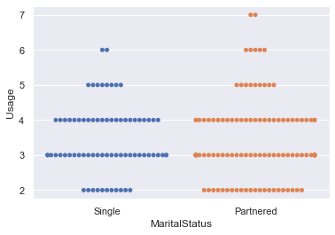

```python
# swarmplot of MaritalStatus and fitness Usage data
sns.swarmplot(x='MaritalStatus',y='Usage',data=cardio_gf_data)
plt.show()
```

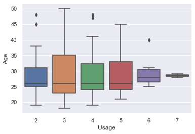

```python
# boxplot of Usage with relation of Age Usage
sns.boxplot(x='Usage',y='Age',data=cardio_gf_data)
plt.show()
```

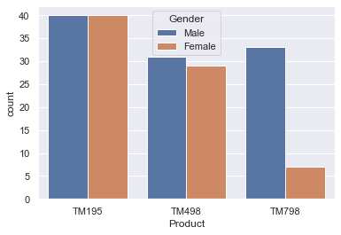

```python
# counter plot of MaritalStatus with gender hue
sns.countplot(cardio_gf_data['Product'], hue = cardio_gf_data['Gender'])
plt.show()
```

Observations:

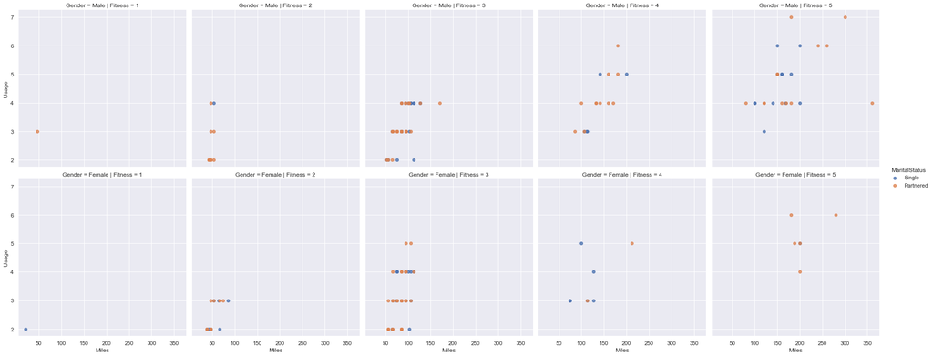

```python
sns.lmplot(x='Miles',y='Usage',data=cardio_gf_data,fit_reg=False,hue='MaritalStatus',row='Gender',col='Fitness')
plt.show()
```

Observations:

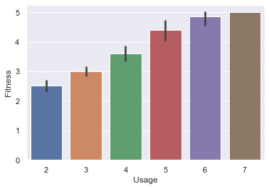

```python
# barplot plot of Usage with Fitness
sns.barplot(cardio_gf_data['Usage'],cardio_gf_data['Fitness'])
```